# Handling Large Geospatial Datasets

When working with large geospatial datasets, data scientists and geoscientists face unique challenges. These datasets are often large in terms of both the number of records (rows) and the complexity of each record (such as detailed polygon geometries). Efficiently handling these datasets requires a combination of strategic data management, appropriate tool selection, and optimized computing practices.

## Theoretical Background

### Key Challenges:

1. **Memory Constraints:** Large datasets may exceed the memory capacity of standard computing environments.
2. **Processing Time:** Complex spatial operations on large datasets can be computationally expensive and time-consuming.
3. **Data Heterogeneity:** Geospatial datasets often combine various types of data, including spatial geometries, time-series data, and traditional numerical or categorical data.

### Strategies for Efficient Data Handling:

#### Efficient I/O Operations:

- **Selective Loading:** Tools like Fiona or GDAL allow reading only the necessary parts of a dataset into memory.
- **File Formats:** Using efficient file formats (e.g., GeoPackage instead of Shapefile) can reduce file size and improve read/write speed.

#### Chunking Data:

- **Batch Processing:** Process data in smaller batches or chunks, fitting within the available memory.
- **Tools:** Pandas and Dask can be used for batch processing. Dask, in particular, is designed for parallel computing and can handle larger-than-memory datasets efficiently.

#### Parallel Processing:

- **Distributed Computing:** Utilizing multiple cores or machines to process data in parallel.
- **Tools:** Libraries like Dask and multiprocessing in Python can facilitate parallel data processing.

## Practical Example

### Scenario:

Imagine you have a large dataset of satellite imagery metadata that includes information on the image capture time, geographic bounding box, and various other attributes.

### Steps for Handling:

#### 1. Reading the Data Efficiently:

Using a library like Fiona to read only necessary attributes:

```
import fiona

with fiona.open('large_dataset.gpkg', 'r') as src:
    for feature in src.filter(bbox=(-120.0, 30.0, -110.0, 40.0)):
        # Process each feature within the bounding box
```

#### 2. Processing in Chunks:

Using Pandas to process data in chunks:

```
import pandas as pd

chunk_size = 10000  # Define chunk size
for chunk in pd.read_csv('large_dataset.csv', chunksize=chunk_size):
    # Process each chunk
```

#### 3. Parallel Processing:

Using Dask for parallel processing:

```
import dask.dataframe as dd

df = dd.read_csv('large_dataset.csv')
result = df.groupby('image_type').mean().compute()  # Perform operations in parallel
```

```python
import pandas as pd
import numpy as np

chunk_size = 10000  # Define chunk size
for chunk in pd.read_csv('quakedata.csv', chunksize=chunk_size):
    # Process each chunk
    print(np.shape(chunk))
```

```
(10000, 22)
(10000, 22)
```

# Spatial Indexing

Spatial indexing is a crucial technique in geospatial data analysis, especially when working with large datasets. It significantly improves the efficiency of spatial queries and operations such as finding nearest neighbors, spatial joins, and range queries.

## Theoretical Background

### Purpose of Spatial Indexing:

- **Efficiency:** Spatial indexing reduces the computational time required for spatial operations by organizing spatial data in a way that makes retrieval faster.

### Types of Spatial Indexes:

#### 1. R-tree:

- **Concept:** An R-tree is a tree-like data structure that stores spatial data. It divides space into hierarchically nested, and possibly overlapping, rectangles. Each node in the tree represents a spatial object (like a point or polygon) or a grouping of objects.
- **Usage:** Widely used in databases and spatial libraries for querying spatial data, like finding all objects within a certain distance or range.

#### 2. Quadtree:

- **Concept:** A Quadtree is another spatial indexing method where space is recursively divided into four quadrants or nodes. Each node represents a specific region of space and contains references to the objects within that region.
- **Usage:** Effective for point data and is used in various applications, including image processing and GIS systems.

## Practical Example

### Scenario:

You have a dataset of geographic locations (like a city's public amenities) and need to frequently query which amenities are within a certain distance of various points (like user locations).

### Implementing R-tree with Geopandas:

Geopandas uses R-tree indexing through the `sindex` property of a GeoDataFrame, which is automatically created when needed.

#### Example Code:

```
import geopandas as gpd
from shapely.geometry import Point, box

# Load your spatial dataset
gdf = gpd.read_file('amenities.shp')

# The spatial index is automatically created
sindex = gdf.sindex

# Define a search box (for example, around a user location)
search_box = box(minx, miny, maxx, maxy)

# Use the spatial index to find intersections
possible_matches_index = list(sindex.intersection(search_box.bounds))
possible_matches = gdf.iloc[possible_matches_index]

# Further filter the possible matches
precise_matches = possible_matches[possible_matches.intersects(search_box)]
```

```python
import geopandas as gpd
from shapely.geometry import Point, box

# Load your spatial dataset
gdf = gpd.read_file('grenoble_amenities.shp')

# The spatial index is automatically created
sindex = gdf.sindex
```

```python
# Define a search box (for example, around a user location)
search_box = box(minx, miny, maxx, maxy)

# Use the spatial index to find intersections
possible_matches_index = list(sindex.intersection(search_box.bounds))
possible_matches = gdf.iloc[possible_matches_index]

# Further filter the possible matches
precise_matches = possible_matches[possible_matches.intersects(search_box)]
```

[output not shown]

# Spatial Interpolation Techniques

## Theoretical Background

### Importance of Spatial Interpolation:

- **Data Enhancement:** Fills gaps in data, allowing for better analysis and decision-making.
- **Surface Prediction:** Generates estimated values for areas where data wasn’t collected, essential in fields like meteorology, hydrology, and environmental science.

### Common Interpolation Methods:

1. **Inverse Distance Weighting (IDW)**
2. **Kriging**
3. **Spline Interpolation**

# Inverse Distance Weighting (IDW)

Inverse Distance Weighting (IDW) is a widely used spatial interpolation method in geosciences and GIS. Its core principle is that the influence of a point on an interpolated value decreases with distance.

## Conceptual Overview

IDW assumes that each measured point has a local influence that diminishes with distance. It assigns weights to measured values based on their distance from the interpolation point, with closer points receiving more weight.

## Theoretical Aspect

The main assumption behind IDW is that the attribute being mapped (like temperature, elevation, or pollution level) changes gradually over space. IDW does not necessarily assume a specific functional form for this change (unlike, say, regression-based methods) but simply assumes that things are "smoother" close to known points.

## Mathematical Aspect

### Formula:

The interpolated value $ V(x_0) $ at a point $ x_0 $ is given by:

$$ V(x_0) = \frac{\sum_{i=1}^{n} w_i \cdot V(x_i)}{\sum_{i=1}^{n} w_i} $$

where:

- $ V(x_i) $ are the known values at each point $ x_i $.
- $ w_i $ are the weights calculated as $ w_i = \frac{1}{{d(x_i, x_0)}^p} $.
- $ d(x_i, x_0) $ is the distance between the known point $ x_i $ and the interpolation point $ x_0 $.
- $ p $ is a power parameter that determines how quickly the influence of a point decreases with distance. A common choice is 2.

### Weighting:

- The weight $ w_i $ decreases as the distance increases, meaning closer points have more influence on the interpolated value.
- As $ p $ increases, the interpolation becomes more local, emphasizing very nearby points more strongly. Conversely, smaller values of $ p $ spread the influence of each point over a larger area.

```python
import numpy as np
from scipy.spatial import distance_matrix

# Sample data: locations (x, y) and temperatures
locations = np.array([[0, 0], [1, 0], [0, 1], [1, 1]])
temperatures = np.array([15, 20, 18, 22])

# Interpolation point
interp_point = np.array([[0.5, 0.5]])

# Compute the distance matrix and apply the IDW formula
distances = distance_matrix(locations, interp_point)
weights = 1 / np.power(distances, 2)
weighted_temps = weights * temperatures[:, np.newaxis]
interp_temp = np.sum(weighted_temps) / np.sum(weights)

print(f"Interpolated Temperature: {interp_temp}")
```

```
Interpolated Temperature: 18.75
```

# Kriging

Kriging is a sophisticated geostatistical procedure that generates an estimated surface from a scattered set of points with z-values. It is widely used in fields like mining, hydrology, and environmental science for spatial interpolation.

## Conceptual Overview

Kriging is based on statistical models that include autocorrelation, the statistical relationship between the points. Unlike simpler interpolation methods, Kriging considers both the distance and the directional relationship between known points when making predictions.

## Theoretical Aspect

Kriging originates from the field of geostatistics and is named after the South African engineer D.G. Krige. The key theoretical foundation of Kriging is the concept of spatial autocorrelation: the idea that points closer together in space are more likely to have similar values than points further apart.

### Types of Kriging:

1. **Ordinary Kriging:** Assumes a constant unknown mean over the entire study area.
2. **Simple Kriging:** Assumes a known mean across the study area.
3. **Universal Kriging:** Incorporates a deterministic trend along with the stochastic model.

## Mathematical Aspect

Kriging estimates an unknown value $ Z(x_0) $ at a location $ x_0 $ using a weighted average of known values $ Z(x_i) $ from surrounding locations.

### Formula:

$$ Z(x_0) = \sum_{i=1}^{n} \lambda_i Z(x_i) $$

where:

- $ \lambda_i $ are weights assigned to each known point $ x_i $.
- The weights are determined based on the variogram model, which describes the degree of spatial dependence between points.

### Variogram:

- The variogram measures the strength of statistical correlation based on the distance between sample points.
- It is a crucial part of the Kriging process as it models the spatial autocorrelation.

## Practice and Solution

### Example Scenario:

You have a set of soil samples with measurements of a certain nutrient and need to create a map estimating nutrient levels across the entire area.

### Python Implementation:

Implementing Kriging often requires more sophisticated libraries like `pykrige` or `scikit-learn`.

#### Sample Code with PyKrige:

```
from pykrige.ok import OrdinaryKriging
import numpy as np

# Sample data: locations (x, y) and nutrient measurements
locations = np.array([[0, 0], [1, 0], [0, 1], [1, 1]])
values = np.array([5.2, 2.8, 4.0, 4.8])

# Create ordinary kriging object
OK = OrdinaryKriging(
    locations[:, 0], locations[:, 1], values,
    variogram_model='linear'
)

# Generate a grid
gridx = np.linspace(0.0, 1.0, 100)
gridy = np.linspace(0.0, 1.0, 100)

# Perform kriging on the grid
z, ss = OK.execute('grid', gridx, gridy)
```

This script will generate a kriged estimate over a grid based on the input sample points.

### Data Sources for Practice:

- **Soil Sampling Data:** Available from agricultural studies or environmental surveys.
- **Meteorological Data:** For practice with climate variables, data can be obtained from sources like NOAA.

Kriging is a powerful tool for spatial analysis, providing a more nuanced and theoretically sound approach to interpolation compared to simpler methods. By incorporating the spatial autocorrelation of data points, Kriging offers more reliable and accurate predictions, especially useful in fields that require precision in spatial analysis.

```
(-0.1, 1.1)
```

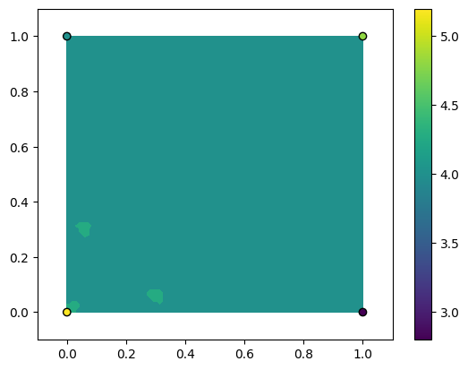

```python
from pykrige.ok import OrdinaryKriging
import numpy as np
import pylab as plt

# Sample data: locations (x, y) and nutrient measurements
locations = np.array([[0, 0], [1, 0], [0, 1], [1, 1]])
values = np.array([5.2, 2.8, 4.0, 4.8])

# Create ordinary kriging object
OK = OrdinaryKriging(
    locations[:, 0], locations[:, 1], values,
    variogram_model='linear'
)

# Generate a grid
gridx = np.linspace(0.0, 1.0, 100)
gridy = np.linspace(0.0, 1.0, 100)

# Perform kriging on the grid
z, ss = OK.execute('grid', gridx, gridy)

plt.contourf(gridx,gridy,z)
plt.scatter(locations[:,0],locations[:,1],c=values,zorder=10,edgecolor='k')
plt.colorbar()
plt.xlim(-0.1,1.1)
plt.ylim(-0.1,1.1)
```

# Spline Interpolation

Spline interpolation is a form of interpolation where the interpolant is a special type of piecewise polynomial called a spline. It is widely used in various fields, such as computer graphics, data fitting, and geospatial analysis, for creating smooth curves or surfaces from discrete data points.

## Conceptual Overview

The main idea behind spline interpolation is to construct a smooth curve that passes through or near a set of data points. Unlike methods that use a single polynomial for the entire data range (which can lead to large oscillations), spline interpolation uses low-degree polynomials in each sub-interval, ensuring smoothness and stability.

## Theoretical Aspect

### Types of Splines:

1. **Linear Splines:** Connect each pair of data points with straight lines. Simple but not very smooth.
2. **Cubic Splines:** Use third-degree polynomials for each interval between points. They ensure that the first and second derivatives of the spline are continuous across the data points.
3. **B-Splines:** A basis for spline functions that provides a numerically stable way to compute splines of any degree.

### Properties:

- **Flexibility:** Splines can create a smooth curve through any number of points.
- **Local Control:** Adjusting one part of a spline does not affect the entire curve, which is advantageous in curve-fitting problems.

## Mathematical Aspect

### Cubic Spline Formula:

A cubic spline is a piecewise function defined by:

$$ S(x) = a_i + b_i(x - x_i) + c_i(x - x_i)^2 + d_i(x - x_i)^3 $$

for $ x_i \leq x < x_{i+1} $, where $ a_i, b_i, c_i, d_i $ are spline coefficients for the interval $ [x_i, x_{i+1}] $, and the coefficients are determined to ensure continuity and smoothness.

### Continuity Conditions:

- **Function Continuity:** $ S(x_i) = y_i $ for each data point $ (x_i, y_i) $.
- **First Derivative Continuity:** The first derivatives of the spline segments must be equal at each data point.
- **Second Derivative Continuity:** The second derivatives of the spline segments must be equal at each data point.

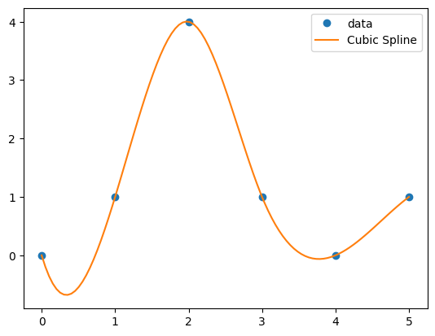

```python
import numpy as np
from scipy.interpolate import CubicSpline
import matplotlib.pyplot as plt

# Sample data points
x = np.array([0, 1, 2, 3, 4, 5])
y = np.array([0, 1, 4, 1, 0, 1])

# Create a cubic spline
cs = CubicSpline(x, y)

# Interpolate and plot
xs = np.linspace(0, 5, 100)
plt.plot(x, y, 'o', label='data')
plt.plot(xs, cs(xs), label="Cubic Spline")
plt.legend()
plt.show()
```

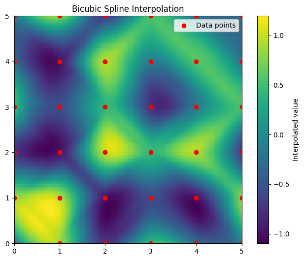

```python
import numpy as np
from scipy.interpolate import griddata
import matplotlib.pyplot as plt

# Sample grid data (x, y)
x = np.array([0, 1, 2, 3, 4, 5])
y = np.array([0, 1, 2, 3, 4, 5])

# Create a meshgrid for the (x, y) points
X, Y = np.meshgrid(x, y)

# Sample z values (for example, a simple function of x and y)
Z = np.sin(X**2 + Y**2)

# Flatten the arrays for griddata input
points = np.vstack([X.ravel(), Y.ravel()]).T
values = Z.ravel()

# Create a grid for interpolation
xi, yi = np.linspace(0, 5, 100), np.linspace(0, 5, 100)
xi, yi = np.meshgrid(xi, yi)

# Perform bicubic interpolation
zi = griddata(points, values, (xi, yi), method='cubic')

# Plot the result
plt.figure(figsize=(8, 6))
plt.imshow(zi, extent=(0, 5, 0, 5), origin='lower')
plt.colorbar(label='Interpolated value')
plt.scatter(X, Y, c='red', label='Data points')
plt.title('Bicubic Spline Interpolation')
plt.legend()
plt.show()
```